# Classifying Disease Status from Gut Microbiome Metagenomics

Matt Aton - DAT 402 - Project 1

## Introduction

For my first project, I will be looking at the [Human Microbiome Project](https://hmpdacc.org/ihmp/) (iHMP) dataset. I pulled the data from [Qiita](https://qiita.ucsd.edu/study/description/11484), and performed some initial processing which is beyond the scope of this project, but if you are curious you can find the basics in the "Linux Commands for Data Processing" document, which I put together for the lab I work in. The dataset contains multiple files which cover 1,569 patients in total. The data file contains metagenomic microbiome data obtained by sequencing fecal samples from the patients. The metadata file contains a few pieces of information about each patient including BMI, age, sex, diagnosis, and whether the patient was taking antibiotics at the time of sample collection.

Microbiome data, and high-throughput sequencing (HTS) data in general, is considered [compositional](https://www.frontiersin.org/articles/10.3389/fmicb.2017.02224/full). This essentially means that the output from the sequencing machine can tell us the relative abundance of the species of bacteria present in each sample, but it can't actually tell us the total abundance of each species in the sample. This also means that the assumption of true independence of our features does not hold for HTS data.

Additionally, each persons microbiome is purportedly as unique as their fingerprints. For this project, this means that there may be features which are only found in a very small percentage of the samples. Of course, the usual method to handle this sort of problem would be imputation or something similar. However, I am going to try a very simple, possibly crude, but potentially very effective method of feature selection which I will investigate in this project.

My idea is to look only at those features which are present in every sample. Surprisingly, as you will see, this amounts to a very small portion of the original 10,000+ features in our data. After seeing what the performance is like when we only look at those features which are present in all samples, I will do a quick and simple look at what happens when we look at features which are in a range of percentiles of the samples.

## Imports

```python
import pandas as pd
import numpy as np
import matplotlib.pyplot as plt
```

```python
from sklearn.ensemble import RandomForestClassifier
from sklearn.svm import SVC
from sklearn.neighbors import KNeighborsClassifier
from sklearn.naive_bayes import GaussianNB
```

```python
from sklearn.model_selection import train_test_split, GridSearchCV, cross_val_score, KFold
from sklearn.metrics import accuracy_score, ConfusionMatrixDisplay, RocCurveDisplay
from sklearn.manifold import TSNE
```

## Read files into dataframes

```python
# set file paths
data_fp = 'data.tsv.xz'
meta_fp = 'metadata_slim.tsv'
```

```python
# the data is tab delimited, and I want the feature ID to be used as the index.
data = pd.read_csv(data_fp, sep='\t', index_col=0)
data.head()
```

| #FeatureID | CSM5FZ3N | CSM5FZ3R | CSM5FZ3T | CSM5FZ3V | CSM5FZ3X | CSM5FZ3Z | CSM5FZ42 | CSM5FZ44 | CSM5FZ46 | CSM5FZ4A | ... | PSMA269W | PSMA26A1 | PSMA26A3 | PSMB4MBI | PSMB4MBK | PSMB4MBS | PSMB4MC1 | PSMB4MC3 | PSMB4MC5 | PSMB4MC7 |
| --- | --- | --- | --- | --- | --- | --- | --- | --- | --- | --- | --- | --- | --- | --- | --- | --- | --- | --- | --- | --- | --- |
| G000005825 | 0 | 0 | 0 | 0 | 0 | 1 | 0 | 0 | 0 | 0 | ... | 0 | 1 | 1 | 1 | 1 | 1 | 1 | 0 | 1 | 0 |
| G000006605 | 0 | 0 | 0 | 0 | 0 | 0 | 0 | 2 | 0 | 0 | ... | 1 | 0 | 0 | 0 | 0 | 0 | 0 | 0 | 0 | 0 |
| G000006725 | 0 | 0 | 0 | 0 | 0 | 0 | 0 | 0 | 0 | 0 | ... | 0 | 0 | 0 | 0 | 0 | 0 | 0 | 0 | 0 | 0 |
| G000006745 | 0 | 0 | 0 | 0 | 1 | 1 | 0 | 0 | 0 | 0 | ... | 0 | 0 | 0 | 0 | 0 | 0 | 0 | 0 | 0 | 0 |
| G000006785 | 4 | 1 | 0 | 0 | 1 | 1 | 1 | 1 | 0 | 1 | ... | 2 | 0 | 0 | 0 | 1 | 0 | 0 | 0 | 1 | 1 |

5 rows × 1569 columns

```python
# transposing so features and samples are in correct orientation
data = data.T
```

```python
# 10,614 species of bactera, 1569 patients
data.shape
```

```
(1569, 10614)
```

```python
# setting this to do filtering when I read the metadata file.
samples = data.index
```

```python
# filtered on samples from above
meta = pd.read_csv(meta_fp, sep='\t', index_col=0).loc[samples]
meta.head()
```

|  | antibiotics | bmi | consent_age | diagnosis | host_subject_id | sex |
| --- | --- | --- | --- | --- | --- | --- |
| CSM5FZ3N | No | NaN | 43.0 | CD | C3001 | female |
| CSM5FZ3R | No | NaN | 43.0 | CD | C3001 | female |
| CSM5FZ3T | No | NaN | 76.0 | CD | C3002 | female |
| CSM5FZ3V | No | NaN | 43.0 | CD | C3001 | female |
| CSM5FZ3X | No | NaN | 76.0 | CD | C3002 | female |

## Handling metadata

```python
# initial check to see what we have.
meta['diagnosis'].value_counts()
```

```
diagnosis
CD        728
UC        430
nonIBD    411
Name: count, dtype: int64
```

```python
# dropping any 'CD' samples
meta = meta[meta['diagnosis'] != 'CD']
meta['diagnosis'].value_counts()
```

```
diagnosis
UC        430
nonIBD    411
Name: count, dtype: int64
```

```python
# make a new column with our diagnosis classes as numeric values
meta['diagnosis_num'] = meta['diagnosis'].map(lambda x: 0 if x == 'nonIBD' else 1)
meta['diagnosis_num'].value_counts()
```

```
diagnosis_num
1    430
0    411
Name: count, dtype: int64
```

## Handling data

We need to drop the samples from the data dataframe that we just dropped from the meta dataframe.

```python
# create a list of those samples which are in data which
# are not in meta
samples = [x for x in data.index if x not in meta.index]
```

```python
# drop those samples from the data
data = data.drop(samples)
```

```python
# here I sort the index of the metadata and columns of the data.
# then I check to see if each entry matches, they do, so we know
# that the samples in meta are the same as the samples in data.
meta = meta.sort_index()
data = data.sort_index()
all(meta.index == data.index)
```

```
True
```

## Data exploration

### What features are present in most samples?

The first thing I'd like to take a look at is whether all the features are present in all samples. I know that usually this is not the case for microbiome data. Every human's gut microbiome is as unique as their fingerprint, so it is expected that not all species of bacteria (features) will be found in every patient's gut.

```python
# create a matrix where the feature will have a 1 if it is present, ie. has a read count of
# at least 1. If the feature count is 0 it will remain zero.
data_count = data.map(lambda x: 0 if x < 1 else 1)
```

```python
# sum up the previously generated matrix by feature. this gives us the total number of samples
# that each feature is found in.
num_samples_present = data_count.sum()
num_samples_present.head()
```

```
#FeatureID
G000005825    319
G000006605    125
G000006725      8
G000006745     93
G000006785    478
dtype: int64
```

```python
# descriptive stats. this is pretty informative, it shows us that 75% of our features are in less
# than 29% (246/841) of our samples.
num_samples_present.describe()
```

```
count    10614.000000
mean       183.062088
std        279.449986
min          0.000000
25%          3.000000
50%         23.000000
75%        246.000000
max        841.000000
dtype: float64
```

#### Look at this!

The figure below and the stats above are pretty mind blowing if you think about it. Of all the 10,000+ features present in the full dataset, half of them are only in 23 of the samples! That's about 3% of the samples! Half of the features are only in 3% of the samples! 75% of the features are only in 29% of the samples! When I looked at this initially, this is where I got the idea to only pay attention to those features which are present in every single sample. Surely, these must be the most predictive features, right? How could a feature which is only present in 3% of the samples be predictive accross the whole dataset? Let's keep going.

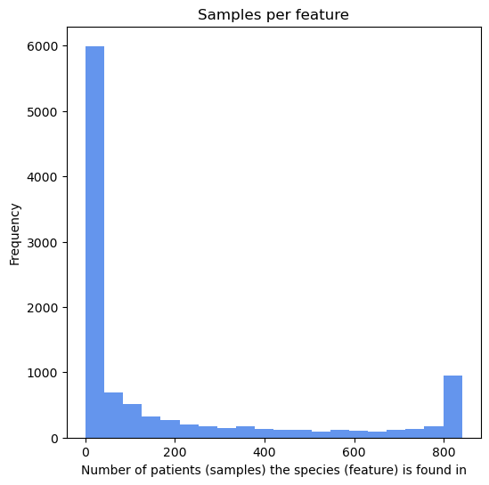

```python
fig1, axs = plt.subplots(1,1, figsize=(6,6))
axs.hist(num_samples_present, bins=20, color='cornflowerblue')
axs.set_xlabel('Number of patients (samples) the species (feature) is found in')
axs.set_ylabel('Frequency')
plt.title('Samples per feature')
```

```python
# here I'm setting the threshold for the features that I want to look at to be 100%.
# what I'm saying here is that I only want to look at features that are present in
# every sample. you can adjust the threshold to see what happens when you
# filter features out more loosely.
th = np.percentile(num_samples_present, 100)
```

```python
# see what the amount of samples needed to be in the set percentile is
th
```

```
841.0
```

```python
features_to_keep = num_samples_present[num_samples_present >= th].index
```

#### How many features am I keeping?

Turns out, from the initial 10,000+ features, only 249 of them are present in every sample. These are the features which I will perform analysis on initially.

```python
# this tells the number of feautres which are present in every sample
len(features_to_keep)
```

```
249
```

```python
# making a new dataframe with only the features which are present in every sample
data_revised = data.loc[:, features_to_keep]
```

```python
data_revised.shape
```

```
(841, 249)
```

## TSNE

Here I am doing a TSNE which I will plot in 3D to see what the data looks like.

```python
# initiate the TSNE
tsne = TSNE(n_components=3, init="random", learning_rate="auto",
            random_state=42)
```

```python
# fit the TSNE and transform the data
X_reduced = tsne.fit_transform(data_revised)
```

```python
# check that the data was reduced to 3 dimensions
X_reduced.shape
```

```
(841, 3)
```

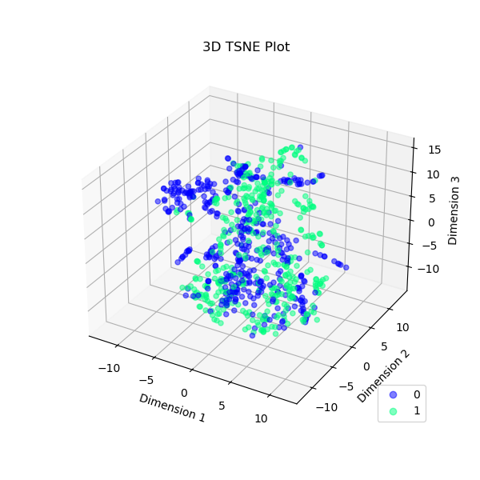

```python
%matplotlib widget
# I'm using matplotlib widget as a way to enable 3D plotting

# fig2, axs = plt.subplots(1,1, figsize=(6,6))
fig2 = plt.figure(figsize=(6,6))
axs = plt.axes(projection='3d')

scatter = axs.scatter3D(X_reduced[:,0], X_reduced[:,1], X_reduced[:,2], c=meta['diagnosis_num'],
             alpha=0.5, cmap='winter')
axs.legend(*scatter.legend_elements(), loc='lower right')
axs.set_xlabel('Dimension 1')
axs.set_ylabel('Dimension 2')
axs.set_zlabel('Dimension 3')
plt.title('3D TSNE Plot')
```

## Transformation

Here we will use counts per million (CPM). This divides the abundance of each species in a sample by the total abundance accross all species in that sample, and then multiplies it by 1 million. We can do this before doing test_train_split because the transformation is only taking place on a per sample basis. The logic here is that sample collection and sequencing runs will have different numbers of DNA sequencing reads, so we can't necessarily directly compare raw frequencies accross samples. To handle this, we divide by the sum of frequencies per sample to get the relative abundance, and then multiply by 1 million to give the numbers a reasonable scale.

```python
# I just transposed here because it was easier than rewriting the code below
data_revised = data_revised.T
data_revised.head()
```

| #FeatureID | CSM5FZ4A | CSM5FZ4E | CSM5FZ4G | CSM5FZ4K | CSM5FZ4M | CSM5MCTZ | CSM5MCU8 | CSM5MCUA | CSM5MCUC | CSM5MCUE | ... | PSMA269S | PSMA269W | PSMA26A1 | PSMA26A3 | PSMB4MBI | PSMB4MBK | PSMB4MC1 | PSMB4MC3 | PSMB4MC5 | PSMB4MC7 |
| --- | --- | --- | --- | --- | --- | --- | --- | --- | --- | --- | --- | --- | --- | --- | --- | --- | --- | --- | --- | --- | --- |
| G000009925 | 92460 | 38249 | 41457 | 20578 | 13624 | 44250 | 55798 | 108650 | 118642 | 65348 | ... | 93410 | 291525 | 165529 | 77306 | 2999 | 1613 | 282402 | 72306 | 52102 | 1466 |
| G000011065 | 80390 | 279089 | 311155 | 90561 | 76110 | 110640 | 35187 | 77463 | 66210 | 51356 | ... | 31452 | 21347 | 41798 | 17826 | 10717 | 22357 | 83046 | 25892 | 16083 | 15048 |
| G000012825 | 2522944 | 908170 | 1462991 | 997447 | 785026 | 2154790 | 1396478 | 2611144 | 1601726 | 1769250 | ... | 604628 | 732059 | 959692 | 901628 | 248711 | 131695 | 1675444 | 1044134 | 806639 | 141533 |
| G000012845 | 323781 | 712385 | 271190 | 127803 | 331006 | 48139 | 105162 | 259449 | 146268 | 88532 | ... | 75116 | 75697 | 91451 | 40462 | 110421 | 34978 | 238438 | 32495 | 28085 | 51889 |
| G000020605 | 29364 | 2259 | 5277 | 2855 | 828 | 140144 | 82029 | 186117 | 235873 | 62241 | ... | 91202 | 125878 | 106896 | 647344 | 138037 | 139049 | 317733 | 30183 | 367272 | 161229 |

5 rows × 841 columns

```python
# I didn't want to rewrite this part, so I just transposed
data_cpm = (data_revised / data_revised.sum()) * 1000000
```

```python
data_cpm = data_cpm.T
data_cpm.head()
```

| #FeatureID | G000009925 | G000011065 | G000012825 | G000012845 | G000020605 | G000027165 | G000144625 | G000146185 | G000153885 | G000153905 | ... | G902363055 | G902363075 | G902363425 | G902363565 | G902363685 | G902363725 | G902363825 | G902364485 | G902385285 | G902387315 |
| --- | --- | --- | --- | --- | --- | --- | --- | --- | --- | --- | --- | --- | --- | --- | --- | --- | --- | --- | --- | --- | --- |
| CSM5FZ4A | 5384.964069 | 4681.995041 | 146938.814496 | 18857.333455 | 1710.189108 | 1.223061 | 1.281302 | 360.919558 | 8.328465 | 24.402984 | ... | 27.606240 | 114.152386 | 3739.131281 | 31.217183 | 28.596337 | 5.940583 | 17.414063 | 35.177572 | 967.383227 | 29.761158 |
| CSM5FZ4E | 1703.687616 | 12431.187038 | 40451.723758 | 31731.064921 | 100.620417 | 3.875155 | 138.525673 | 22.716429 | 47.704500 | 1713.397776 | ... | 613.209951 | 289.656738 | 744.742528 | 64.630467 | 210.371947 | 40.755946 | 58.082790 | 55.187559 | 1304.145722 | 152.200073 |
| CSM5FZ4G | 1684.554947 | 12643.406288 | 59446.866060 | 11019.476953 | 214.424499 | 8.086124 | 376.593947 | 27.915412 | 83.705603 | 1347.944648 | ... | 1310.155225 | 803.248720 | 1288.985021 | 167.898812 | 412.026610 | 56.968571 | 139.658329 | 133.847697 | 919.055016 | 207.069783 |
| CSM5FZ4K | 1572.398410 | 6919.913129 | 76216.545654 | 9765.634850 | 218.155188 | 13.448446 | 304.576735 | 30.182592 | 104.760337 | 4737.826367 | ... | 952.318077 | 764.956773 | 904.560811 | 183.005841 | 456.559457 | 91.846773 | 149.079079 | 152.899661 | 1013.218141 | 1326.582213 |
| CSM5FZ4M | 1537.687451 | 8590.237220 | 88602.805986 | 37359.349115 | 93.453113 | 6.094768 | 128.780195 | 13.995394 | 31.376770 | 675.729211 | ... | 285.099714 | 295.483393 | 1077.306717 | 90.067130 | 146.274437 | 17.832840 | 51.918396 | 56.094441 | 971.438336 | 234.197112 |

5 rows × 249 columns

### Test_train_split

```python
# just seeing what our classes look like again. 0 is 'nonIBD' and 1 is 'UC'
meta['diagnosis_num'].value_counts()
```

```
diagnosis_num
1    430
0    411
Name: count, dtype: int64
```

```python
X = data_cpm
y = meta['diagnosis_num'].values.ravel()

X_train, X_test, y_train, y_test = train_test_split(X, y, random_state=42)
```

```python
X_train.shape
```

```
(630, 249)
```

```python
X_test.shape
```

```
(211, 249)
```

## Model Selection by 10-fold Cross Validation

```python
# I've heard that SVM is good for high dimensionality, randomforest is good for everything, KNN just because,
# Naivebayes cuz why not
svm = SVC()
rf = RandomForestClassifier()
nb = GaussianNB()
knn = KNeighborsClassifier()
```

```python
# get average balanced accuracy scores for each model with 10-fold CV.
models = [svm, rf, nb, knn]
for i, v in enumerate(models):
    accs = cross_val_score(v, X_train, y_train, scoring='accuracy', cv=10)
    print(f'{v}\n', pd.Series(accs).describe(), '\n')
```

```
SVC()
 count    10.000000
mean      0.863492
std       0.038300
min       0.809524
25%       0.841270
50%       0.865079
75%       0.888889
max       0.920635
dtype: float64

RandomForestClassifier()
 count    10.000000
mean      0.953968
std       0.015785
min       0.920635
25%       0.952381
50%       0.952381
75%       0.968254
max       0.968254
dtype: float64

GaussianNB()
 count    10.000000
mean      0.752381
std       0.046247
min       0.666667
25%       0.746032
50%       0.746032
75%       0.785714
max       0.825397
dtype: float64

KNeighborsClassifier()
 count    10.000000
mean      0.874603
std       0.039203
min       0.809524
25%       0.849206
50%       0.880952
75%       0.900794
max       0.936508
dtype: float64
```

## Training models

From above it looks like the KNeighborsClassifier and the RandomForestClassifier perform best. But I know that KNeighborsClassifier is very sensitive to high dimensionality, wherease the SVC should handle dimensionality better, so I will go with Random Forest and Support Vector Machine as my two models.

### Random Forest

Here I'll train a RandomForestClassifier on the data and see how it does.

```python
# instantiate the model
forest_model = RandomForestClassifier(random_state=42)
```

```python
# fit the model
forest_model.fit(X_train, y_train)
```

```
RandomForestClassifier(random_state=42)
```

```python
# use the trained model to make predictions on the test data
forest_preds = forest_model.predict(X_test)
```

```python
# see the performance of the model on the test data
accuracy_score(y_test, forest_preds)
```

```
0.9289099526066351
```

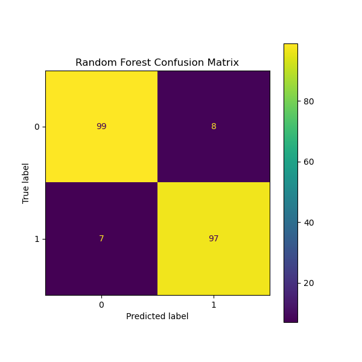

```python
# plot confusion matrix
fig3, axs = plt.subplots(1,1, figsize=(6,6))
ConfusionMatrixDisplay.from_predictions(y_test, forest_preds, ax=axs)
plt.title("Random Forest Confusion Matrix")
```

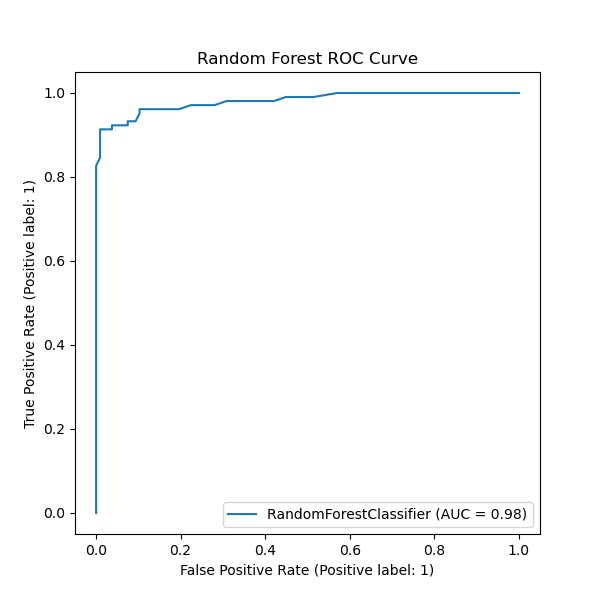

```python
fig4, axs = plt.subplots(1,1, figsize=(6,6))
RocCurveDisplay.from_estimator(forest_model, X_test, y_test, ax=axs)
plt.title('Random Forest ROC Curve')
```

### SVC

Here I will train a support vectore machine classifier and see how it performs

```python
# instantiate the model
svc_model = SVC()
```

```python
# fit the model
svc_model.fit(X_train, y_train)
```

```
SVC()
```

```python
# make predictions on the test data
svc_preds = svc_model.predict(X_test)
```

```python
# see the performance on test data
accuracy_score(y_test, svc_preds)
```

```
0.8578199052132701
```

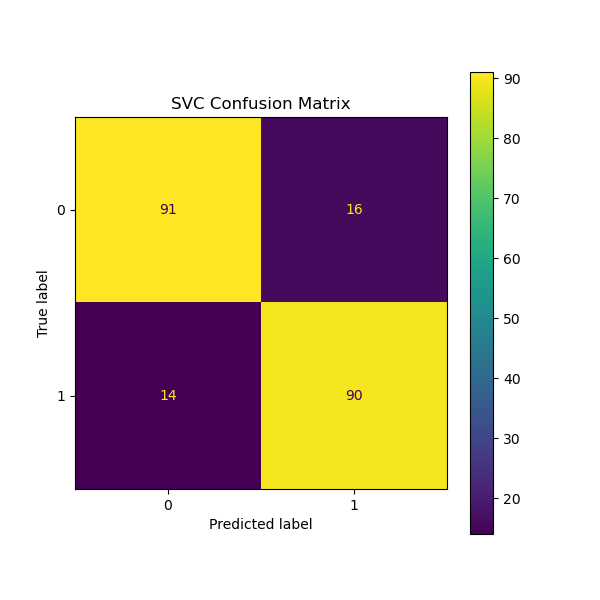

```python
fig5, axs = plt.subplots(1,1, figsize=(6,6))
ConfusionMatrixDisplay.from_predictions(y_test, svc_preds, ax=axs)
plt.title('SVC Confusion Matrix')
```

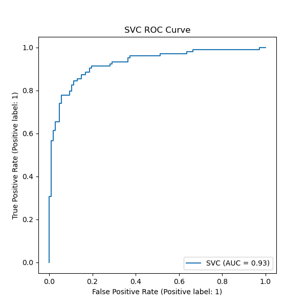

```python
fig6, axs = plt.subplots(1,1, figsize=(6,6))
RocCurveDisplay.from_estimator(svc_model, X_test, y_test, ax=axs)
plt.title('SVC ROC Curve')
```

### Hyperparameter Tuning: SVC

```python
# hyperparameter tuning
params = {'C': range(1,20)}
svc_tuned_model = SVC()
grid_search = GridSearchCV(svc_tuned_model, params, cv=KFold(n_splits=10, shuffle=True), scoring='accuracy')
grid_search.fit(X_train, y_train)
```

```
GridSearchCV(cv=KFold(n_splits=10, random_state=None, shuffle=True),
             estimator=SVC(), param_grid={'C': range(1, 20)},
             scoring='accuracy')
```

```python
# store best value of C in a variable
c_best = grid_search.best_params_['C']
c_best
```

```
14
```

```python
# instantiate tuned model
svc_tuned_model = SVC(C=c_best)
```

```python
# fit tuned model
svc_tuned_model.fit(X_train, y_train)
```

```
SVC(C=14)
```

```python
# make predictions on test data
svc_tuned_preds = svc_tuned_model.predict(X_test)
```

```python
# see accuracy score of tuned model
accuracy_score(y_test, svc_tuned_preds)
```

```
0.9241706161137441
```

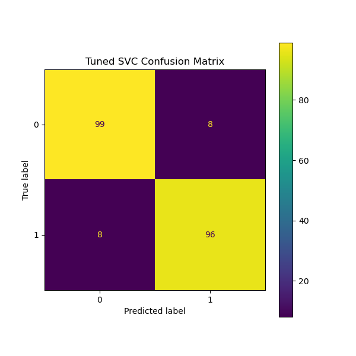

```python
fig7, axs = plt.subplots(1,1, figsize=(6,6))
ConfusionMatrixDisplay.from_predictions(y_test, svc_tuned_preds, ax=axs)
plt.title('Tuned SVC Confusion Matrix')
```

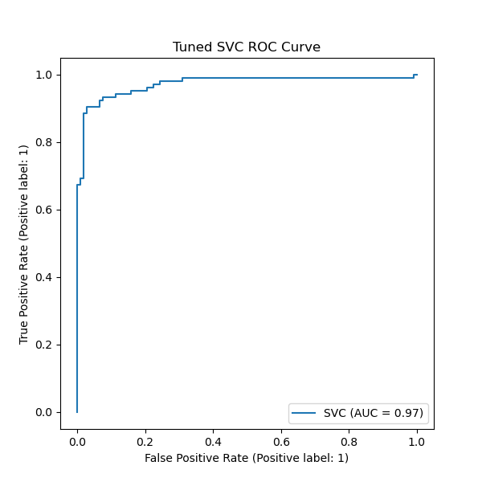

```python
fig8, axs = plt.subplots(1,1, figsize=(6,6))
RocCurveDisplay.from_estimator(svc_tuned_model, X_test, y_test, ax=axs)
plt.title('Tuned SVC ROC Curve')
```

### Okay, but what about all the other features?

I'm curious what happens when we try to train models on different numbers of features based on the percent of samples which those features are found in. For instance, the whole notebook up till this point has been looking at only those features which are present in all samples, or 100%. What happens when we look at all the features which are in at least 60% of the samples, or 75%? Below, I wrote some code that will loop through various thresholds from 1% to 100%. These thresholds represent the percent of samples that features must be present in, in order to be kept for model training and testing. I ran it 5 times, using different random seeds for each run, in what is kind of like a weird sloppy cross-validation. The idea is that I want to get an average accross a set of models, not just look at the performance of one model with one random seed.

```python
threshs = range(1, 101, 3)
acc_total = []
noise = [1, 2, 3, 4, 5]

for i in noise:
    acc = []
    for j in threshs:
        # get the feature tables
        th = np.percentile(num_samples_present, j)
        features_to_keep = num_samples_present[num_samples_present >= th].index
        data_revised = data.loc[:, features_to_keep]

        # perform transformation
        data_revised = data_revised.T
        data_cpm = (data_revised / data_revised.sum()) * 1000000
        data_cpm = data_cpm.T

        # test_train_split
        X = data_cpm
        y = meta['diagnosis_num'].values.ravel()
        X_train, X_test, y_train, y_test = train_test_split(X, y, random_state=42*i)

        # instantiate model
        model = RandomForestClassifier(random_state=42*i)

        # train model
        model.fit(X_train, y_train)

        # predict on test data
        preds = model.predict(X_test)

        # get accuracy score
        acc.append(accuracy_score(y_test, preds))

    acc_total.append(acc)
```

```python
# split the output into individual runs
first = np.asarray(acc_total[0])
second = np.asarray(acc_total[1])
third = np.asarray(acc_total[2])
fourth = np.asarray(acc_total[3])
fifth = np.asarray(acc_total[4])
```

```python
# take the average of the 5 runs
avg = (first + second + third + fourth + fifth) / 5
avg
```

```
array([0.94881517, 0.94881517, 0.94881517, 0.95734597, 0.95734597,
       0.95734597, 0.95734597, 0.95734597, 0.95734597, 0.96018957,
       0.95260664, 0.96208531, 0.96113744, 0.95545024, 0.96018957,
       0.96018957, 0.95924171, 0.96113744, 0.95734597, 0.95545024,
       0.95545024, 0.95829384, 0.95924171, 0.95165877, 0.96208531,
       0.96018957, 0.95734597, 0.9563981 , 0.96018957, 0.96682464,
       0.96113744, 0.95829384, 0.94123223, 0.93933649])
```

```python
# fit a 2nd degree polynomial to the average
feature_model = np.poly1d(np.polyfit(threshs, avg, 2))
line = np.linspace(0,100)
```

```python
# fit a 2nd degree polynomial to the average, less the last two values (outliers)
feature_model_ = np.poly1d(np.polyfit(threshs[0:-3], avg[0:-3], 2))
line_ = np.linspace(0,100)
```

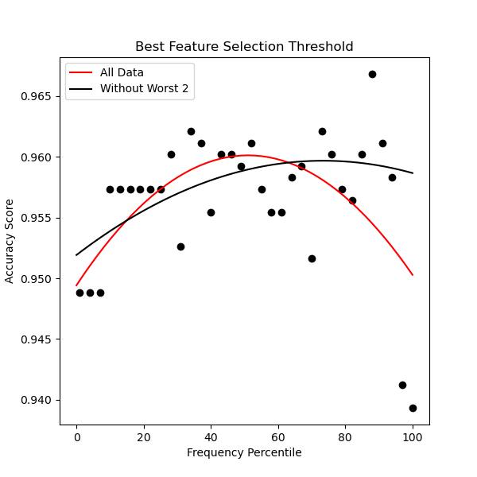

```python
fig4, axs = plt.subplots(1,1, figsize=(6,6))
plt.plot(line, feature_model(line), color='red', lw=1.5)
plt.plot(line_, feature_model_(line_), color='black', lw=1.5)
plt.legend(['All Data', 'Without Worst 2'])
plt.scatter(threshs, avg, color='black')
plt.title('Best Feature Selection Threshold')
axs.set_ylabel('Accuracy Score')
axs.set_xlabel('Frequency Percentile')
```